# Práctica herramientas de programación

Guillermo González Díaz

14/10/2021

### *Cargamos las librerías que usaremos en el trabajo*

```r
 library(readr)
 library(janitor)
```

```r
 library(tibble)
 library(ggplot2)
 library(tidyverse)
```

### *Ejercicio 1*

#### Create a data frame called df_mmmm and clean it with the janitor package,

```r
df_mmm<-read.csv("~/Desktop/R/practica_a_entregar/mktmix.csv",
                 na=c("NA","Nan",""))

df_mmm<-janitor::clean_names(df_mmm)
head(df_mmm)
```

```
##   new_vol_sales base_price radio in_store newspaper_inserts discount       tv
## 1         19564   15.02928   245   15.452              <NA>    0.000 101.7800
## 2         19387   15.02928   314   16.388              <NA>    0.000  76.7340
## 3         23889   14.58509   324   62.692              <NA>    0.050 131.5902
## 4         20055   15.33289   298   16.573              <NA>    0.000 119.6271
## 5         20064   15.64263   279   41.504              <NA>    0.045 103.4381
## 6         19481   15.48699   259   20.404              <NA>    0.000 128.4014
##     stout website_campaign
## 1 2.28342             <NA>
## 2 2.22134             <NA>
## 3 2.00604             <NA>
## 4 2.19897             <NA>
## 5 1.81860             <NA>
## 6 2.29155             <NA>
```

### *Eercicio 2*

#### What are the classes of base_price and discount? How many columns and rows are there ?

```r
class(df_mmm$base_price)
```

```
## [1] "numeric"
```

```r
class(df_mmm$discount)
```

```
## [1] "numeric"
```

```r
nrow(df_mmm)
```

```
## [1] 104
```

```r
ncol(df_mmm)
```

```
## [1] 9
```

### *Ejercicio 3*

#### Turn newspaper_insert’s class into Numeric.

```r
class(df_mmm$newspaper_inserts)
```

```
## [1] "character"
```

```r
df_mmm <- df_mmm %>%
  mutate(newspaper_inserts = replace_na(newspaper_inserts, 0),
         newspaper_inserts = if_else(newspaper_inserts == "Insert", 1, 0 ))

table(df_mmm$newspaper_inserts)
```

```
##
##  0  1
## 98  6
```

```r
class(df_mmm$newspaper_inserts)
```

```
## [1] "numeric"
```

### *Ejercicio 4*

#### How many values are there in website_campaign (NA does not count)

```r
values_in_dfmmm <- table(df_mmm$website_campaign)

df_mmm <- df_mmm %>%
  mutate(website_campaign = replace_na(website_campaign, 0))
table(df_mmm$website_campaign)
```

```
##
##                0         Facebook          Twitter Website Campaign
##               90                4                4                6
```

#### Create new columns from each category defined as: 1 if website campaign equals Facebook and 0 if it does not, same with all.

```r
df_mmm <- df_mmm %>%
  mutate(facebook=if_else(website_campaign=="Facebook", 1, 0),
         twitter=if_else(website_campaign=="Twitter",1,0),
         website_campaign=if_else(website_campaign=="Website Campaign",1,0))

glimpse(df_mmm)
```

```
## Rows: 104
## Columns: 11
## $ new_vol_sales     <int> 19564, 19387, 23889, 20055, 20064, 19481, 19509, 190…
## $ base_price        <dbl> 15.02928, 15.02928, 14.58509, 15.33289, 15.64263, 15…
## $ radio             <dbl> 245, 314, 324, 298, 279, 259, 235, 290, 315, 318, 32…
## $ in_store          <dbl> 15.452, 16.388, 62.692, 16.573, 41.504, 20.404, 32.4…
## $ newspaper_inserts <dbl> 0, 0, 0, 0, 0, 0, 0, 0, 0, 0, 0, 0, 0, 0, 0, 0, 0, 0…
## $ discount          <dbl> 0.00000000, 0.00000000, 0.05000000, 0.00000000, 0.04…
## $ tv                <dbl> 101.78000, 76.73400, 131.59020, 119.62706, 103.43812…
## $ stout             <dbl> 2.28342, 2.22134, 2.00604, 2.19897, 1.81860, 2.29155…
## $ website_campaign  <dbl> 0, 0, 0, 0, 0, 0, 0, 0, 0, 0, 0, 0, 0, 0, 0, 0, 0, 0…
## $ facebook          <dbl> 0, 0, 0, 0, 0, 0, 0, 0, 0, 0, 0, 1, 1, 1, 1, 0, 0, 0…
## $ twitter           <dbl> 0, 0, 0, 0, 0, 0, 0, 0, 0, 0, 0, 0, 0, 0, 0, 0, 0, 0…
```

### *Ejercicio 5*

#### Create a line plot with ggplot2 showing the evolution of new_vol_sales, which would be the target variable in a model. Since we haven’t been provided withdates, you will have to invent an x axis (it can be just numbers from 1 and so on).

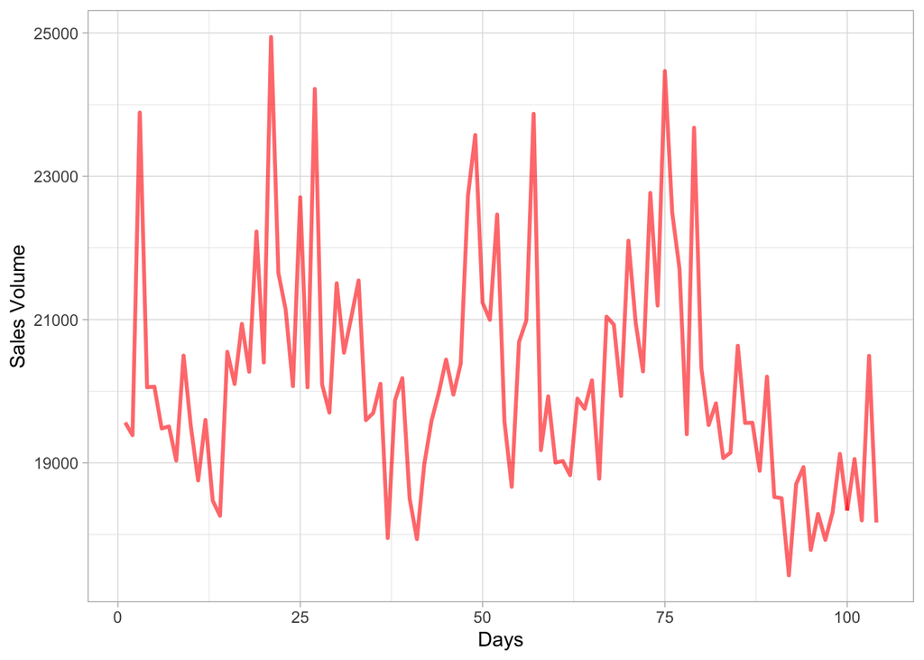

```r
new_vol_sales_evolution <- df_mmm %>%
  ggplot()+
  theme_light() +
  geom_line(aes(x=c(1:104),y=new_vol_sales), colour="red", alpha=0.6,
            size=1, lty="solid")+
  labs(x="Days", y="Sales Volume")

new_vol_sales_evolution
```

### *Ejercicio 6*

#### Create a histogram and a boxplot of the same variable. Based on the plots, which is the median of the variable? Calculate it with an R function. Were you close?

### *Histogram*

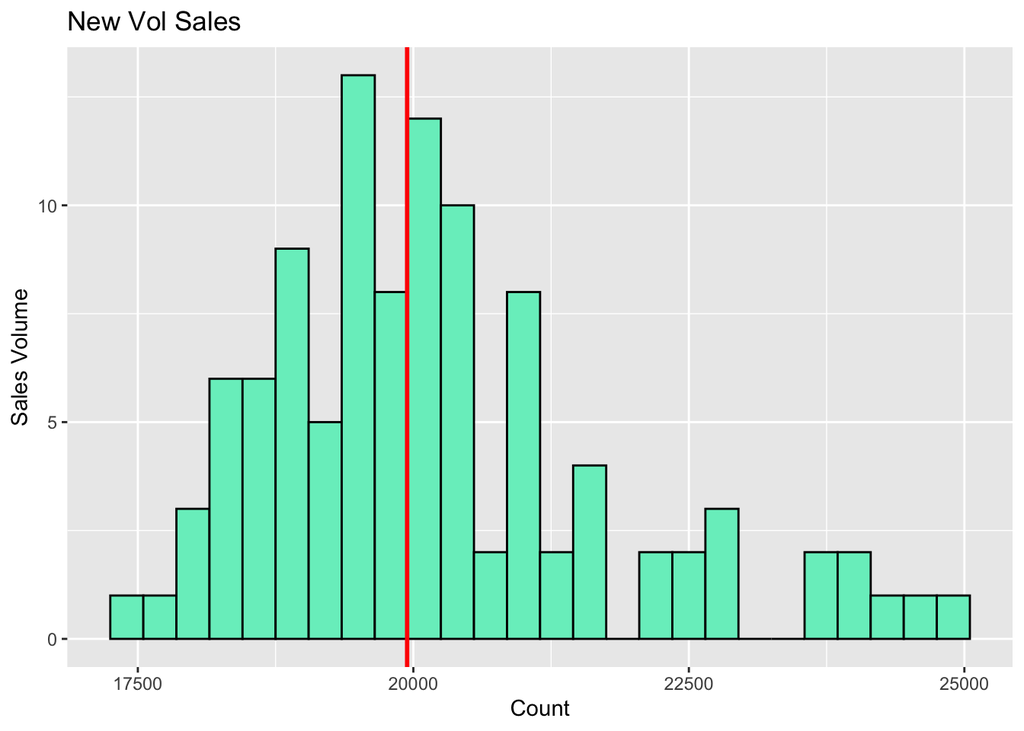

```r
df_mmm %>%
  ggplot() +
  geom_histogram(aes(x=new_vol_sales), color="black", fill = I("aquamarine2"),
                 binwidth = 300) +
  labs(x="Count", y="Sales Volume", title = "New Vol Sales") +
  geom_vline(aes(xintercept = median(new_vol_sales)),col='red',size=1)
```

### *ßoxplot*

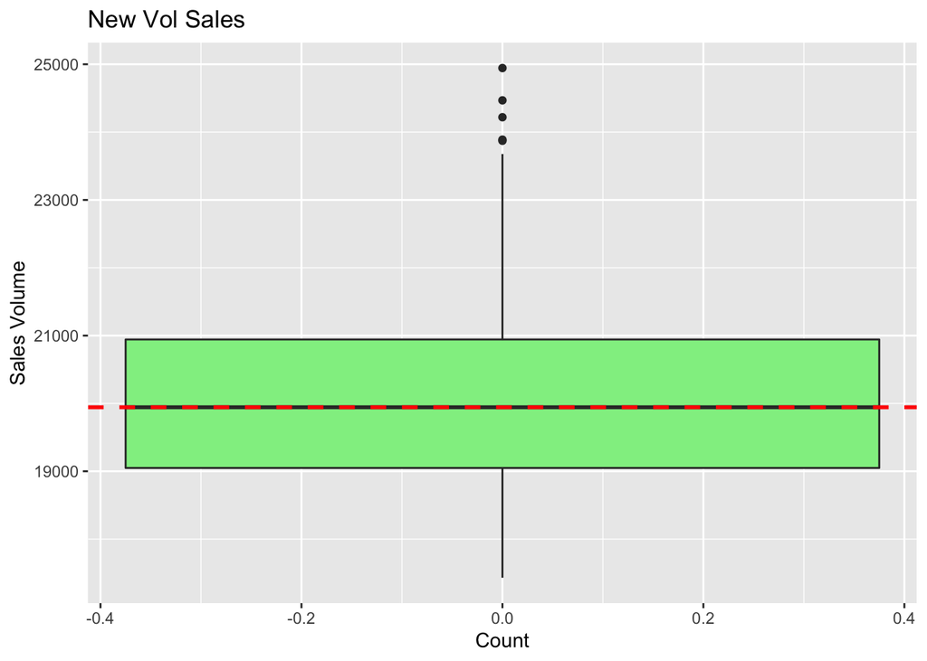

```r
df_mmm %>%
  ggplot() +
  geom_boxplot(aes(y=new_vol_sales), fill="lightgreen") +
  labs(x="Count", y="Sales Volume", title = "New Vol Sales") +
  geom_hline(aes(yintercept = median(new_vol_sales)), col ="red", size = 1,
             linetype=2,)
```

```r
mean_new_vol_sales <- mean(df_mmm$new_vol_sales)
mean_new_vol_sales
```

```
## [1] 20171.07
```

### *Ejercicio 7*

#### Select only the media investment columns: tv, radio and stout, and create a new data frame just with them. Use this data frame and the provided code for creating a plot with the evolution of these three columns. This should be a plot in an only figure, with a share x axis but different y axis (see the result). For using the provided code, suppose the data frame you created with just the media data is called df_media. Is there anything worth mentioning from the plot?

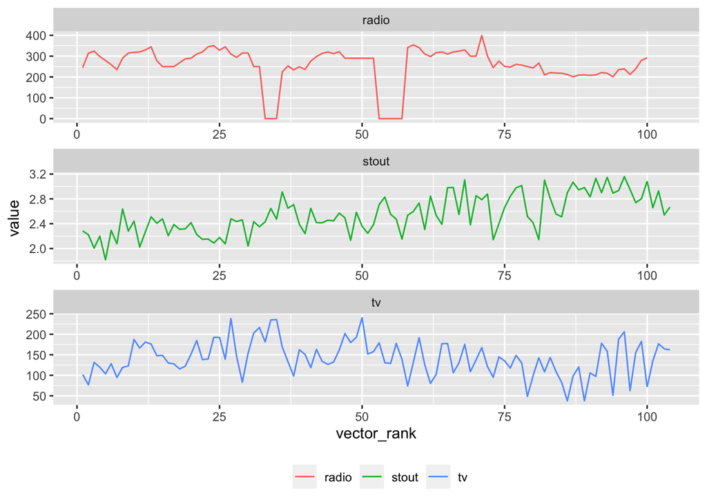

```r
df_media <- df_mmm %>%
  select(tv, radio, stout)


df_media <- df_media %>%
  pivot_longer(everything())

vector_rank <- rep(1:104, each = 3)
df_media <- cbind(df_media, vector_rank)


ggplot(df_media, aes(x = vector_rank, y = value, col = name)) +
  geom_line() +
  facet_wrap(~name, nrow=3, scales = "free") +
  theme(legend.position = "bottom") +
  theme(legend.title = element_blank())
```

#### **Es destacable que hay dos grupos de días en los que no existen inversiones en radio, a parte de los últimos días del período, en los que los valores de radio son desconocidos.**

### *Ejercicio 8*

#### in_store is an index of the stock available on stores for selling the product.Create a scatter plot with ggplot2 for comparing the new_vol_sales column against in_store. Choose carefully which column should be set on the x axis and which on the y, considering that new_vol_sales will be the target variable on a model, i.e., the analyst will want to explain this variable based on the rest of the information. Explain your decision and also comment anything interesting from the plot. For doing this, think about the relation that could exist between the stock of a product and its sales.

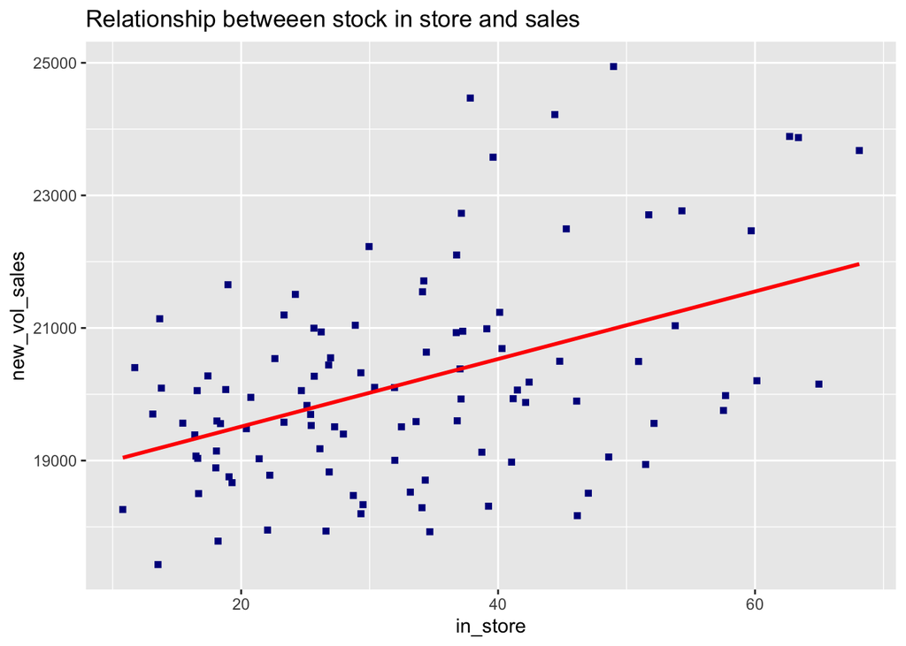

```r
df_mmm %>%
  ggplot(aes(x=in_store, y=new_vol_sales)) +
  geom_point(shape=15,color="darkblue", size=1.5)+
  geom_smooth(method = "lm",
              se = FALSE,
              aes(x=in_store, y=new_vol_sales), colour="red") +
  labs(title="Relationship betweeen stock in store and sales")
```

#### **New_vol_sales será la que queramos predecir, por eso tiene que ir en el eje y. Como yo lo entiendo en el eje x la causa y el eje y el efecto.**

#### **En el gráfico, dibujando la línea, se puede ver que si existe relación en cuanto a > stock en tienda, mayores son las ventas. No obstante, hay otras cosas a tener en cuenta como el precio de mantener productos en el almacén. Si decidimos colorear los puntos en función de los anuncios en peródico como hacemos en el siguiente ejercicio, se ve que no tiene un gran efecto en las ventas el hecho de anunciarse en el periódico.**

### *Exercise 9*

#### Create two different versions of the previous plot: -Color each dot differently based on the newspaper_inserts column (using as.factor() here is recommended). -Color each dot differently based on the tv column.

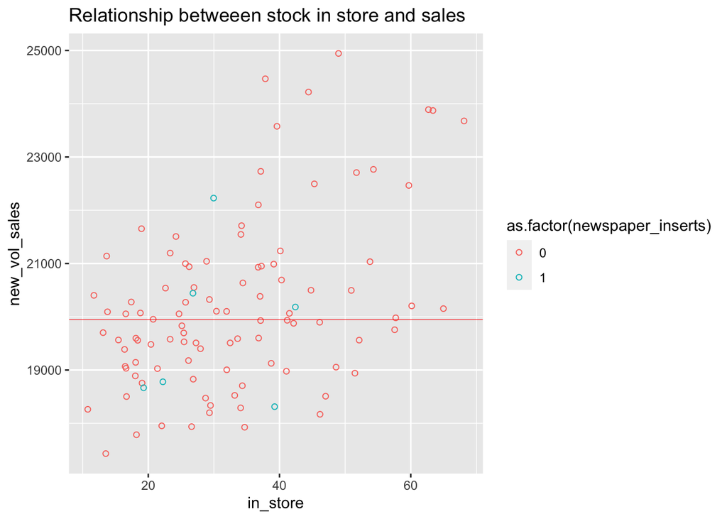

```r
df_mmm %>%
  ggplot(aes(x=in_store, y=new_vol_sales)) +
  geom_point(shape=1, size=1.5, aes(col=as.factor(newspaper_inserts))) +
  labs(title="Relationship betweeen stock in store and sales") +
  geom_hline(aes(yintercept = median(new_vol_sales)),col='red',size=0.2)
```

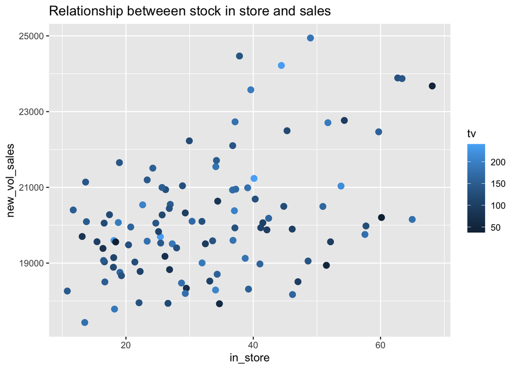

```r
df_mmm %>%
  ggplot(aes(x=in_store, y=new_vol_sales)) +
  geom_point(size=2.5, aes(col=tv)) +
  labs(title="Relationship betweeen stock in store and sales")
```

### *Ejercicio 10*

#### Create another column on the data frame indicating whether a discount has been applied or not. You can name discount_yesno, for example. The column can be numerical or logical. After that, create another data frame aggregating the original one, for calculating the average base price when there’s a discount and where it isn’t. Use this data frame for creating a column plot with ggplot. On the x axis you should use the discount_yesno values and on the y axis, the average price you calculated. Are the any significant differences? Remark. Try not to create new data frames nor overwriting the original one, but chain all the operations with %>%, including the plot.

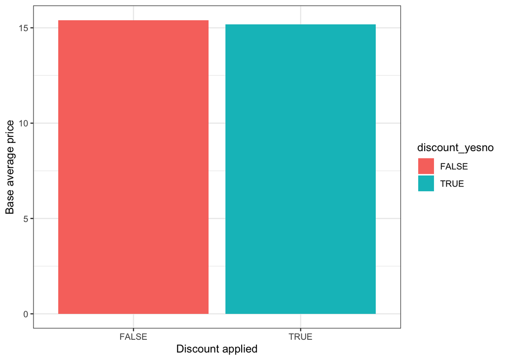

```r
df_mmm %>%
  mutate(discount_yesno = if_else(discount != 0, TRUE, FALSE)) %>%
  group_by(discount_yesno) %>%
  summarise(base_price_average=mean(base_price)) %>%
  ggplot(aes(x=discount_yesno, y=base_price_average, fill=discount_yesno))+
  geom_bar(stat = "identity", position = "dodge")+
  xlab("Discount applied")+
  theme_bw()+
  ylab("Base average price")
```

#### **En los gráficos puede verse que no existe una gran diferencia en la media del base_price haya o no descuento. Otro estudio interesante sería comprobar si con el descuento aplicado el volumen de ventas es mayor o menor.**

### *Ejercicio 11*

#### Create a function that fits a model on this dataset using the provided code.The idea of the function is selecting a subset of columns on the data frame, creating a data frame with this selection, using the data frame on a model and returning a number that will indicate how good the model is. So the input will be a character, that will be the names of the columns, and the output will be this fitness number, provided in the next piece of code. You have been asked to create an auxiliary data frame with the radio stout tv value selection of columns: for this piece of code we are assuming you’ve called the data frame df_aux but you can name it as you want and change the code.

```r
my_select <- function (cols) {
    if (!"new_vol_sales" %in% cols) {
    cols= c(cols, "new_vol_sales")
    print(cols) }
    if(!all(cols %in% colnames(df_mmm))){
      stop("Columnas no presentes en el data frame")
    }
  df_aux  <- df_mmm[,cols]
  my_model<- lm(new_vol_sales ~ ., data = df_aux)
  summary(my_model)$adj.r.squared

}

cols <- c("in_store", "base_price","new_vol_sales")
my_select(cols)
```

```
## [1] 0.6030317
```

### *Ejercicio 12*

#### You are given three sets of variables. Create a list whose elements will be these three vector. Now, using map_dbl() or sapply(), call the function you created in the previous exercise for the three cases. Which of the three subsets provide the best model, bearing in mind that the larger the returned number, the better?

```r
c1 <- c("base_price", "radio", "tv", "stout")
c2 <- c("base_price", "in_store", "discount", "radio", "tv", "stout")
c3 <- c("in_store", "discount")

lista_pruebas <- list(c1,c2,c3)

sapply(lista_pruebas, my_select)
```

```
## [1] "base_price"    "radio"         "tv"            "stout"
## [5] "new_vol_sales"
## [1] "base_price"    "in_store"      "discount"      "radio"
## [5] "tv"            "stout"         "new_vol_sales"
## [1] "in_store"      "discount"      "new_vol_sales"
```

```
## [1] 0.6906219 0.7836765 0.2033219
```

#### **El mejor modelo lo explica c2, lo cual tiene sentido ya que estamos intentando explicar la variable independiente volumen de ventas en función de otras independientes, y en c2 están incluidas todas las de los otros dos vectores, por lo tanto tiene que ser superior.**